# Teoría de respuesta al ítem

July 15, 2015

## Teoría clásica del test

Los fundamentos de la teoría actual están cimentados en la teoría clásica del test. Antes de formular cualquier modelo, es necesario verificar el comportamiento de los ítems que componen la prueba y de las habilidades de las personas que fueron expuestas a la prueba.

## Librerías de interés

Se proponene las siguientes librerías para realizar la programación automatizada de las estadísticas descriptivas de un test. Todas ellas pueden ser descardas del CRAN http://cran.r-project.org.

- `ggplot2`, `gridExtra` - Para mejorar el entorno gráfico.
- `dplyr` - Para manejar bases de datos.
- `psych`, `CTT`, `CMC` - Implementan medidas clásicas de confiabiliad de las pruebas.
- `lavaan`, `semPlot` - Ejecutan análisis de componentes principales y análisis factoriales exploratorios y confirmatorios.
- `ltm`, `mirt` - Muestran algunos gráficos de interés.

## Carga de las librerías

```r
library(ggplot2)
library(gridExtra)
library(dplyr)
library(CTT)
library(CMC)
library(lavaan)
library(semPlot)
library(psych)
library(ltm)
library(mirt)
```

## SAT12 - conjunto de datos

Este conjunto de datos contiene 32 ítems del *science assesment test* (SAT) aplicados a 600 estudiantes de grado 12.

```r
data(SAT12)
dim(SAT12)
```

```
## [1] 600  32
```

```r
head(SAT12)
```

```
##   Item.1 Item.2 Item.3 Item.4 Item.5 Item.6 Item.7 Item.8 Item.9 Item.10
## 1      1      4      5      2      3      1      2      1      3       1
## 2      3      4      2      8      3      3      2      8      3       1
## 3      1      4      5      4      3      2      2      3      3       2
## 4      2      4      4      2      3      3      2      4      3       2
## 5      2      4      5      2      3      2      2      1      1       2
## 6      1      4      3      1      3      2      2      3      3       1
##   Item.11 Item.12 Item.13 Item.14 Item.15 Item.16 Item.17 Item.18 Item.19
## 1       2       4       2       1       5       3       4       4       1
## 2       2       8       2       1       5       2       4       1       1
## 3       2       1       3       1       5       5       4       1       3
## 4       2       4       2       1       5       2       4       1       3
## 5       2       4       2       1       5       4       4       5       1
## 6       2       3       2       1       5       5       4       4       1
##   Item.20 Item.21 Item.22 Item.23 Item.24 Item.25 Item.26 Item.27 Item.28
## 1       4       3       3       4       1       3       5       1       3
## 2       4       3       3       8       1       8       4       1       4
## 3       4       3       3       1       1       3       4       1       3
## 4       4       3       1       5       2       5       4       1       3
## 5       4       3       3       3       1       1       5       1       3
## 6       4       3       3       4       1       1       4       1       4
##   Item.29 Item.30 Item.31 Item.32
## 1       1       5       4       5
## 2       5       8       4       8
## 3       4       4       4       1
## 4       4       2       4       2
## 5       1       2       4       1
## 6       2       3       4       3
```

## Ejercicio

Teniendo en cuenta que la opción 8 representa una omisión, realice un análisis de las opciones de respuesta que los estudiantes escogieron.

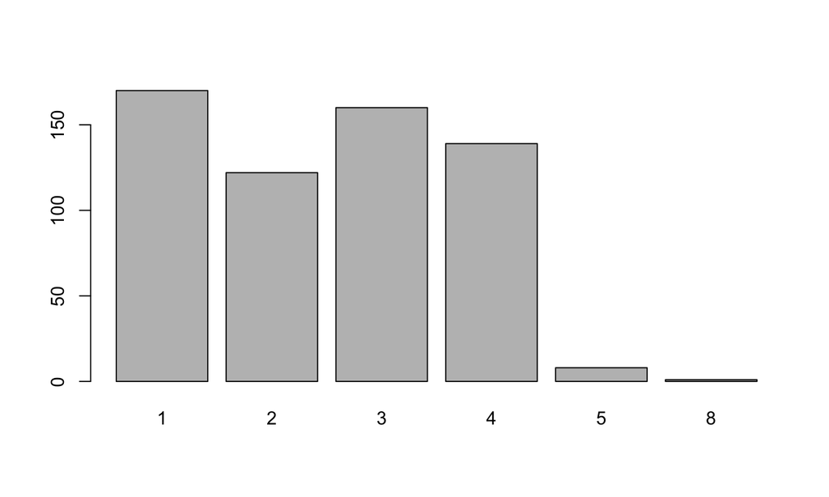

```r
plot(as.factor(SAT12$Item.1))
```

## La clave

En un test de opción múltiple, la clave se refiere a la opción considerada como correcta. De esta forma, los datos con varias categorías se convierten en un conjunto de unos y ceros. **¿Qué pasa con las omisiones?**

```r
# La clave para cada ítem
key <- c(1,4,5,2,3,1,2,1,3,1,2,4,2,1,5,3,4,4,1,4,3,3,4,1,3,5,1,3,1,5,4,5)

# Matriz de unos y ceros
Ex1 <- key2binary(SAT12,key)
head(Ex1)
```

```
##      Item.1 Item.2 Item.3 Item.4 Item.5 Item.6 Item.7 Item.8 Item.9
## [1,]      1      1      1      1      1      1      1      1      1
## [2,]      0      1      0      0      1      0      1      0      1
## [3,]      1      1      1      0      1      0      1      0      1
## [4,]      0      1      0      1      1      0      1      0      1
## [5,]      0      1      1      1      1      0      1      1      0
## [6,]      1      1      0      0      1      0      1      0      1
##      Item.10 Item.11 Item.12 Item.13 Item.14 Item.15 Item.16 Item.17
## [1,]       1       1       1       1       1       1       1       1
## [2,]       1       1       0       1       1       1       0       1
## [3,]       0       1       0       0       1       1       0       1
## [4,]       0       1       1       1       1       1       0       1
## [5,]       0       1       1       1       1       1       0       1
## [6,]       1       1       0       1       1       1       0       1
##      Item.18 Item.19 Item.20 Item.21 Item.22 Item.23 Item.24 Item.25
## [1,]       1       1       1       1       1       1       1       1
## [2,]       0       1       1       1       1       0       1       0
## [3,]       0       0       1       1       1       0       1       1
## [4,]       0       0       1       1       0       0       0       0
## [5,]       0       1       1       1       1       0       1       0
## [6,]       1       1       1       1       1       1       1       0
##      Item.26 Item.27 Item.28 Item.29 Item.30 Item.31 Item.32
## [1,]       1       1       1       1       1       1       1
## [2,]       0       1       0       0       0       1       0
## [3,]       0       1       1       0       0       1       0
## [4,]       0       1       1       0       0       1       0
## [5,]       1       1       1       1       0       1       0
## [6,]       0       1       0       0       0       1       0
```

## Número de aciertos

Esta es una medida bastante utilizada en la descripción de la *dificultad* de los ítems

```r
# proporciones de aciertos
prop <- colMeans(Ex1)
head(prop)
```

```
##    Item.1    Item.2    Item.3    Item.4    Item.5    Item.6
## 0.2833333 0.5683333 0.2800000 0.3783333 0.6200000 0.1600000
```

```r
# varianza
var <- prop * (1 - prop)
head(var)
```

```
##    Item.1    Item.2    Item.3    Item.4    Item.5    Item.6
## 0.2030556 0.2453306 0.2016000 0.2351972 0.2356000 0.1344000
```

## Ejercicio

Revise estos gráficos con detenemimiento. ¿Observa algo insual en el comportamiento de las proporciones?

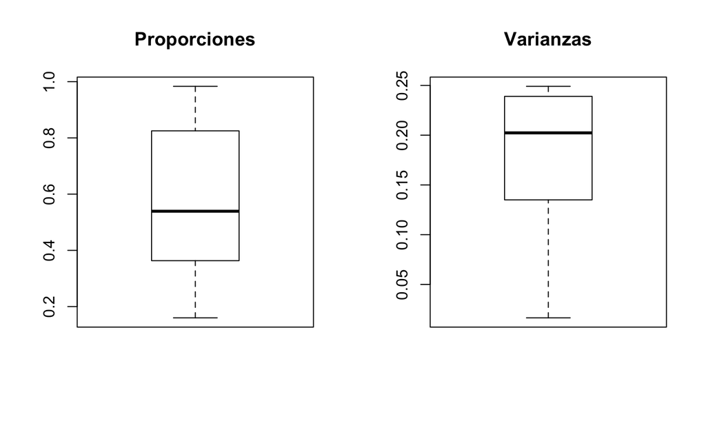

```r
par(mfrow = c(1,2))
boxplot(prop, main="Proporciones"); boxplot(var, main="Varianzas")
```

## Construyendo una *escala* para la habilidad

La habilidad (del estudiante) es una función del número de respuestas correctas (p.ej. suma de los unos y ceros o el promedio).

```r
# proporciones estandarizadas
habilidad <- rowMeans(Ex1)
head(habilidad)
```

```
## [1] 1.00000 0.53125 0.56250 0.50000 0.68750 0.62500
```

```r
mean(habilidad)
```

```
## [1] 0.5688021
```

```r
sd(habilidad)
```

```
## [1] 0.1579292
```

Un ejercicio primario consiste en estandarizar las habilidades observadas en la prueba (también se podría estandarizar las dificultades).

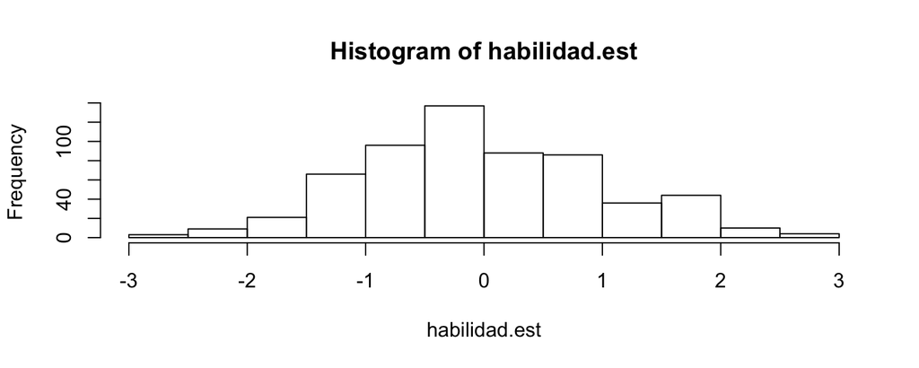

```r
habilidad.est <- scale(habilidad)
hist(habilidad.est)
```

## Construyendo una *escala* para la dificultad

Un ejercicio primario consiste en estandarizar las proporciones de aciertos observadas en la prueba.

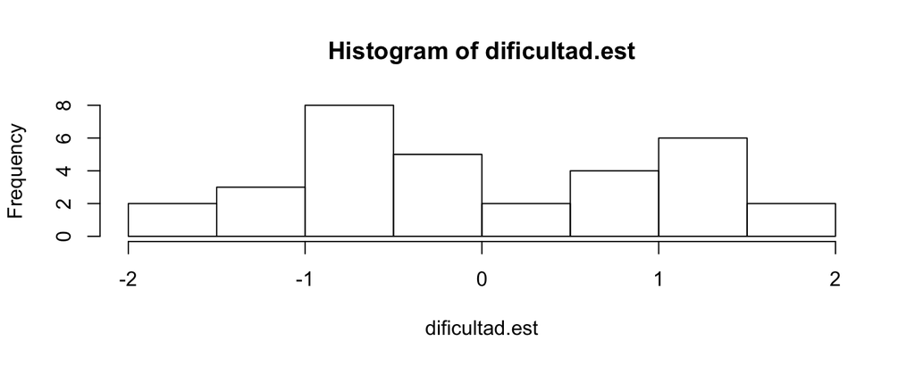

```r
dificultad.est <- scale(prop)
hist(dificultad.est)
```

## Habilidades y dificultades observadas

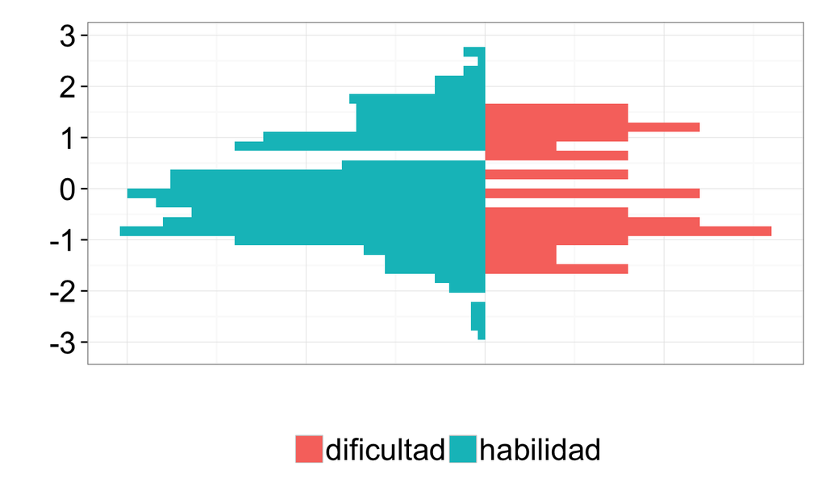

## Puntaje de la prueba

La calificación final de la prueba por lo general se establece con base en una escala predefinida antes de la aplicación del examen.

```r
score <- 5 + 2 * habilidad.est
mean(score); sd(score)
```

```
## [1] 5
```

```
## [1] 2
```

```r
min(score); max(score)
```

```
## [1] -0.6202664
```

```
## [1] 10.46065
```

## Puntaje de la prueba

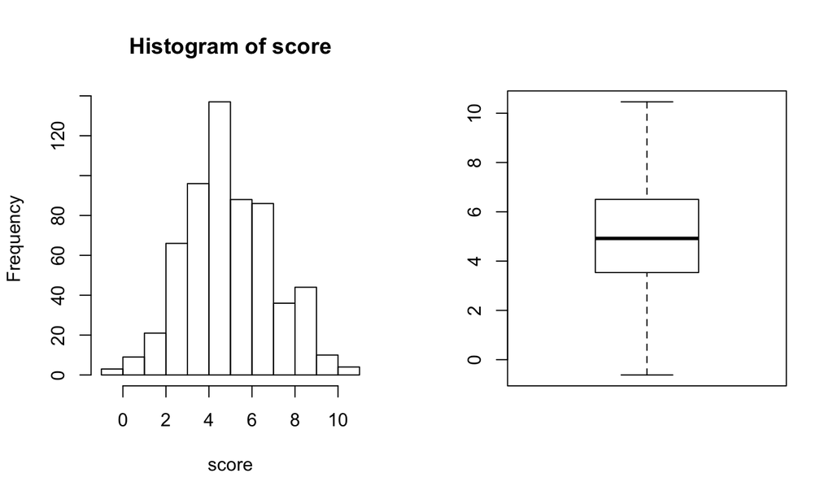

```r
par(mfrow=c(1, 2))
hist(score)
boxplot(score)
```

## Gráficos de ítems

Los siguientes gráficos muestran el comportamiento de la población en cada uno de los puntajes (vistos como factor) de los ceros y unos para cada ítem. Es deseable que el gráfico muestre agregaciones en ceros (a la izquierda), unos (a la derecha) y cajas que cubran el espectro de cero a uno (en el centro).

```r
data <- data.frame(Ex1, score = score, hab = habilidad)
p1 <- qplot(as.factor(score), Item.1, data = data, geom = c("boxplot"))
p2 <- qplot(as.factor(score), Item.2, data = data, geom = c("boxplot"))
p3 <- qplot(as.factor(score), Item.3, data = data, geom = c("boxplot"))
p4 <- qplot(as.factor(score), Item.4, data = data, geom = c("boxplot"))
```

## Gráficos de ítems

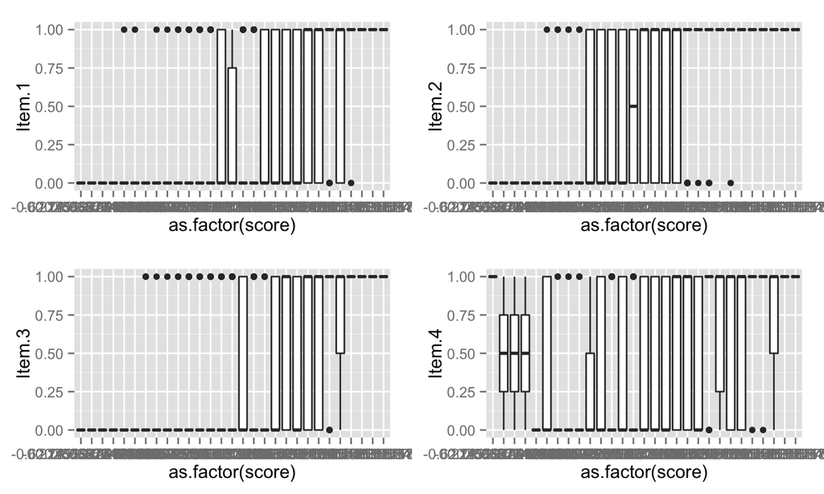

```r
grid.arrange(p1,p2,p3,p4)
```

## Discriminación

```r
N <- nrow(Ex1)
p <- ncol(Ex1)

data1 <- data %>% arrange(score)
data1$hab <- 'medio'
data1$hab[c(1:round(N * 0.3))] <- 'bajo'
data1$hab[c(round(N * 0.7) :N)] <- 'alto'

boxplot(data1$Item.1 ~ data1$hab)
boxplot(data1$Item.2 ~ data1$hab)
boxplot(data1$Item.3 ~ data1$hab)
boxplot(data1$Item.4 ~ data1$hab)
```

## Discriminación

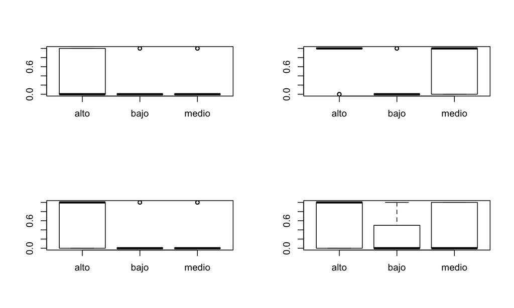

## Discriminación

```r
V1.hab <- data1 %>% group_by(hab) %>% summarise(prop = mean(Item.1))
V2.hab <- data1 %>% group_by(hab) %>% summarise(prop = mean(Item.2))
V3.hab <- data1 %>% group_by(hab) %>% summarise(prop = mean(Item.3))
V4.hab <- data1 %>% group_by(hab) %>% summarise(prop = mean(Item.4))

disc1 <- V1.hab[1, "prop"] - V1.hab[2, "prop"]
disc2 <- V2.hab[1, "prop"] - V2.hab[2, "prop"]
disc3 <- V3.hab[1, "prop"] - V3.hab[2, "prop"]
disc4 <- V4.hab[1, "prop"] - V4.hab[2, "prop"]
```

## Discriminación

```r
V1.hab; V2.hab
```

```
## Source: local data frame [3 x 2]
##
##     hab      prop
## 1  alto 0.4972376
## 2  bajo 0.1222222
## 3 medio 0.2426778
```

```
## Source: local data frame [3 x 2]
##
##     hab      prop
## 1  alto 0.8895028
## 2  bajo 0.2333333
## 3 medio 0.5774059
```

## Discriminación

```r
disc1; disc2; disc3; disc4
```

```
##        prop
## 1 0.3750153
```

```
##        prop
## 1 0.6561694
```

```
##        prop
## 1 0.4469306
```

```
##        prop
## 1 0.3743094
```

**¿Cuáles son los ítems que más discriminan y por qué?**

## Azar

```r
data2 <- filter(data, score < 1)
colMeans(data2)
```

```
##     Item.1     Item.2     Item.3     Item.4     Item.5     Item.6
## 0.08333333 0.00000000 0.00000000 0.33333333 0.08333333 0.08333333
##     Item.7     Item.8     Item.9    Item.10    Item.11    Item.12
## 0.25000000 0.16666667 0.58333333 0.00000000 0.83333333 0.25000000
##    Item.13    Item.14    Item.15    Item.16    Item.17    Item.18
## 0.00000000 0.41666667 0.33333333 0.00000000 0.75000000 0.00000000
##    Item.19    Item.20    Item.21    Item.22    Item.23    Item.24
## 0.00000000 0.41666667 0.58333333 0.33333333 0.08333333 0.16666667
##    Item.25    Item.26    Item.27    Item.28    Item.29    Item.30
## 0.00000000 0.00000000 0.25000000 0.08333333 0.33333333 0.08333333
##    Item.31    Item.32      score        hab
## 0.16666667 0.00000000 0.43505883 0.20833333
```

**¿Cuál es la diferencia entre el item 11 y el item 13?**

## Curva característica del ítem

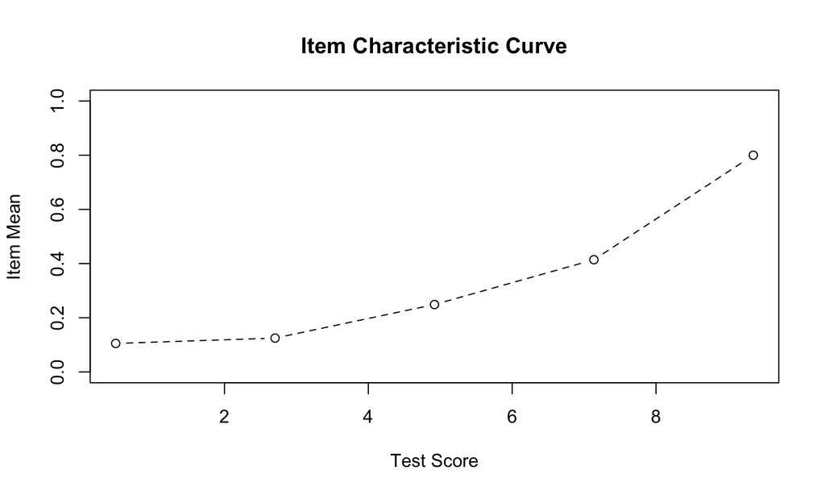

```r
cttICC(data$score, data$Item.1)
```

## Curva característica del ítem

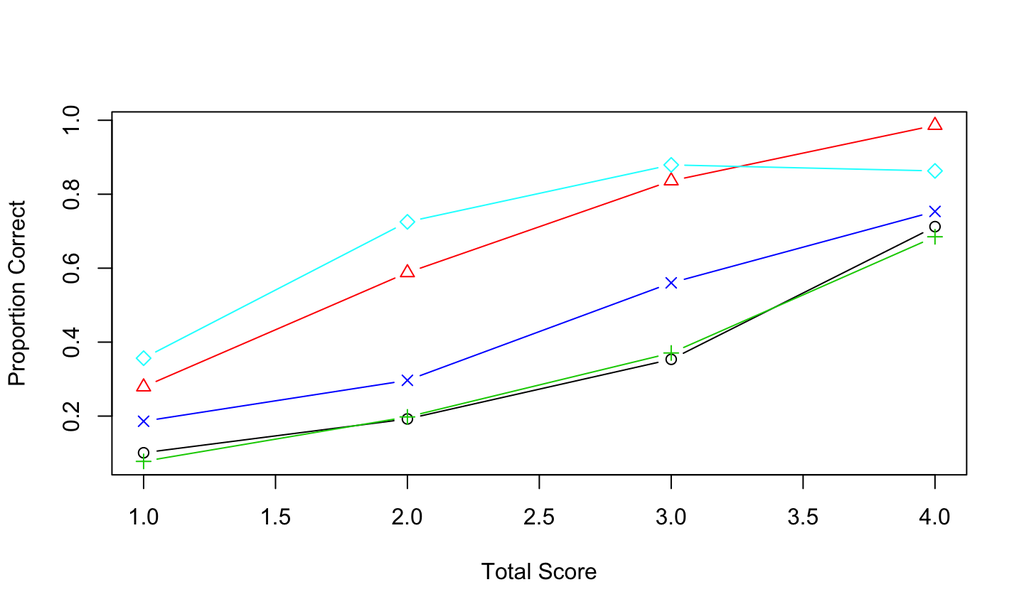

```r
dsc <- descript(Ex1[,1:5], 3)
plot(dsc, type = "b", lty = 1, pch = 1:5)
```

## Confiabilidad de la prueba

```r
reliability(Ex1)
```

```
##
##  Number of Items
##  32
##
##  Number of Examinees
##  600
##
##  Coefficient Alpha
##  0.798
```